# Model Health Cockpit

Single-pane operational model health, governance, and evidence.

**Champion (defensible):** choose the primary model using *inner temporal validation* on temporal-train rows only—never because it wins group holdout or another diagnostic slice alone. **Temporal holdout** reports forward-time behavior at the frozen threshold. Diagnostic splits are context, not a second crown.

NO-GO - At least one binding deployment check failed.

Updated: 2026-04-24 14:23:40 Selected model: oof_calibrated_stack Temporal split strategy: latest_cutoff_with_minimum_positive_support Maturity gate pass: False Gate profile: balanced Models in cockpit (union): logistic_regression, lightgbm, xgboost, catboost, soft_vote_lr_lightgbm, oof_calibrated_stack, knn, oof_calibrated_stack_all_bases, random_forest, soft_vote_4_bases

View Controls

Mode: Grid

Toggle affects metric sections only. Evidence charts: shared gallery plus per-model rasters when generated.

**Temporal test rows**

6521

**Temporal positives**

58

**Temporal positive rate**

0.0089

**Dataset positive rate**

0.0338

**Deploy: Temporal Primary (Required)**

False

**Deploy: Recent Operational Window (Advisory)**

False

## Temporal Holdout (Primary)

Test rows: 6521 Test positives: 58 Positive rate: 0.0089

### Model Metrics

| Model | Precision | Recall | F1 | ROC-AUC | PR-AUC |
| --- | --- | --- | --- | --- | --- |
| logistic_regression | 0.4533 | 0.5862 | 0.5113 | 0.9096 | 0.3582 |
| lightgbm | 0.2947 | 0.4828 | 0.3660 | 0.8138 | 0.2013 |
| xgboost | 0.1571 | 0.5172 | 0.2410 | 0.8253 | 0.1944 |
| catboost | 0.1351 | 0.3448 | 0.1942 | 0.8503 | 0.1293 |
| soft_vote_lr_lightgbm | 0.3214 | 0.4655 | 0.3803 | 0.9161 | 0.3334 |
| oof_calibrated_stack | 0.4098 | 0.4310 | 0.4202 | 0.9365 | 0.3264 |
| knn | 0.4444 | 0.0690 | 0.1194 | 0.7907 | 0.1787 |
| oof_calibrated_stack_all_bases | 0.5000 | 0.3621 | 0.4200 | 0.9310 | 0.3204 |
| random_forest | 0.1204 | 0.7414 | 0.2072 | 0.9277 | 0.2261 |
| soft_vote_4_bases | 0.4348 | 0.3448 | 0.3846 | 0.9301 | 0.3189 |

### Baselines

| Baseline | Accuracy | F1 | PR-AUC | Recall | Precision |
| --- | --- | --- | --- | --- | --- |
| always_negative | 0.9911 | 0.0000 | 0.0089 | 0.0000 | 0.0000 |
| prevalence_random | 0.9528 | 0.0065 | 0.0089 | 0.0172 | 0.0040 |

### Lift vs Baseline

| Model | Baseline | Delta F1 | Delta PR-AUC | Delta Recall | Delta Precision |
| --- | --- | --- | --- | --- | --- |
| logistic_regression | prevalence_random | 0.5048 | 0.3493 | 0.5690 | 0.4494 |
| lightgbm | prevalence_random | 0.3596 | 0.1924 | 0.4655 | 0.2908 |
| xgboost | prevalence_random | 0.2345 | 0.1856 | 0.5000 | 0.1531 |
| catboost | prevalence_random | 0.1877 | 0.1204 | 0.3276 | 0.1312 |
| soft_vote_lr_lightgbm | prevalence_random | 0.3738 | 0.3245 | 0.4483 | 0.3175 |
| oof_calibrated_stack | prevalence_random | 0.4137 | 0.3175 | 0.4138 | 0.4059 |
| knn | prevalence_random | 0.1130 | 0.1699 | 0.0517 | 0.4405 |
| oof_calibrated_stack_all_bases | prevalence_random | 0.4135 | 0.3115 | 0.3448 | 0.4960 |
| random_forest | prevalence_random | 0.2008 | 0.2172 | 0.7241 | 0.1165 |
| soft_vote_4_bases | prevalence_random | 0.3782 | 0.3100 | 0.3276 | 0.4308 |

### Model Metrics

Sort cards:

logistic_regression

Precision

0.4533

0.001.00

Recall

0.5862

0.001.00

F1

0.5113

0.001.00

ROC-AUC

0.9096

0.001.00

PR-AUC

0.3582

0.001.00

lightgbm

Precision

0.2947

0.001.00

Recall

0.4828

0.001.00

F1

0.3660

0.001.00

ROC-AUC

0.8138

0.001.00

PR-AUC

0.2013

0.001.00

xgboost

Precision

0.1571

0.001.00

Recall

0.5172

0.001.00

F1

0.2410

0.001.00

ROC-AUC

0.8253

0.001.00

PR-AUC

0.1944

0.001.00

catboost

Precision

0.1351

0.001.00

Recall

0.3448

0.001.00

F1

0.1942

0.001.00

ROC-AUC

0.8503

0.001.00

PR-AUC

0.1293

0.001.00

soft_vote_lr_lightgbm

Precision

0.3214

0.001.00

Recall

0.4655

0.001.00

F1

0.3803

0.001.00

ROC-AUC

0.9161

0.001.00

PR-AUC

0.3334

0.001.00

oof_calibrated_stack

Precision

0.4098

0.001.00

Recall

0.4310

0.001.00

F1

0.4202

0.001.00

ROC-AUC

0.9365

0.001.00

PR-AUC

0.3264

0.001.00

knn

Precision

0.4444

0.001.00

Recall

0.0690

0.001.00

F1

0.1194

0.001.00

ROC-AUC

0.7907

0.001.00

PR-AUC

0.1787

0.001.00

oof_calibrated_stack_all_bases

Precision

0.5000

0.001.00

Recall

0.3621

0.001.00

F1

0.4200

0.001.00

ROC-AUC

0.9310

0.001.00

PR-AUC

0.3204

0.001.00

random_forest

Precision

0.1204

0.001.00

Recall

0.7414

0.001.00

F1

0.2072

0.001.00

ROC-AUC

0.9277

0.001.00

PR-AUC

0.2261

0.001.00

soft_vote_4_bases

Precision

0.4348

0.001.00

Recall

0.3448

0.001.00

F1

0.3846

0.001.00

ROC-AUC

0.9301

0.001.00

PR-AUC

0.3189

0.001.00

### Baselines

always_negative

Accuracy

0.9911

0.001.00

F1

0.0000

0.001.00

PR-AUC

0.0089

0.001.00

Recall

0.0000

0.001.00

Precision

0.0000

0.001.00

prevalence_random

Accuracy

0.9528

0.001.00

F1

0.0065

0.001.00

PR-AUC

0.0089

0.001.00

Recall

0.0172

0.001.00

Precision

0.0040

0.001.00

### Lift vs Baseline

logistic_regression

Baseline: prevalence_random

Delta F1

0.5048

-1.001.00

Delta PR-AUC

0.3493

-1.001.00

Delta Recall

0.5690

-1.001.00

Delta Precision

0.4494

-1.001.00

lightgbm

Baseline: prevalence_random

Delta F1

0.3596

-1.001.00

Delta PR-AUC

0.1924

-1.001.00

Delta Recall

0.4655

-1.001.00

Delta Precision

0.2908

-1.001.00

xgboost

Baseline: prevalence_random

Delta F1

0.2345

-1.001.00

Delta PR-AUC

0.1856

-1.001.00

Delta Recall

0.5000

-1.001.00

Delta Precision

0.1531

-1.001.00

catboost

Baseline: prevalence_random

Delta F1

0.1877

-1.001.00

Delta PR-AUC

0.1204

-1.001.00

Delta Recall

0.3276

-1.001.00

Delta Precision

0.1312

-1.001.00

soft_vote_lr_lightgbm

Baseline: prevalence_random

Delta F1

0.3738

-1.001.00

Delta PR-AUC

0.3245

-1.001.00

Delta Recall

0.4483

-1.001.00

Delta Precision

0.3175

-1.001.00

oof_calibrated_stack

Baseline: prevalence_random

Delta F1

0.4137

-1.001.00

Delta PR-AUC

0.3175

-1.001.00

Delta Recall

0.4138

-1.001.00

Delta Precision

0.4059

-1.001.00

knn

Baseline: prevalence_random

Delta F1

0.1130

-1.001.00

Delta PR-AUC

0.1699

-1.001.00

Delta Recall

0.0517

-1.001.00

Delta Precision

0.4405

-1.001.00

oof_calibrated_stack_all_bases

Baseline: prevalence_random

Delta F1

0.4135

-1.001.00

Delta PR-AUC

0.3115

-1.001.00

Delta Recall

0.3448

-1.001.00

Delta Precision

0.4960

-1.001.00

random_forest

Baseline: prevalence_random

Delta F1

0.2008

-1.001.00

Delta PR-AUC

0.2172

-1.001.00

Delta Recall

0.7241

-1.001.00

Delta Precision

0.1165

-1.001.00

soft_vote_4_bases

Baseline: prevalence_random

Delta F1

0.3782

-1.001.00

Delta PR-AUC

0.3100

-1.001.00

Delta Recall

0.3276

-1.001.00

Delta Precision

0.4308

-1.001.00

### Primary Diagnostics

Primary Dials (oof_calibrated_stack)

Precision

0.4098

0.001.00

Recall

0.4310

0.001.00

F1

0.4202

0.001.00

PR-AUC

0.3264

0.001.00

F1 Leaderboard Rails

logistic_regression

0.5113

lightgbm

0.3660

xgboost

0.2410

catboost

0.1942

soft_vote_lr_lightgbm

0.3803

oof_calibrated_stack

0.4202

knn

0.1194

oof_calibrated_stack_all_bases

0.4200

random_forest

0.2072

soft_vote_4_bases

0.3846

### Delta Diagnostics

Delta Dials (oof_calibrated_stack)

Delta F1

0.4137

-1.001.00

Delta PR-AUC

0.3175

-1.001.00

Delta Recall

0.4138

-1.001.00

Delta Precision

0.4059

-1.001.00

## Group Holdout (Diagnostic)

Test rows: 6205 Test positives: 197 Positive rate: 0.0317

### Model Metrics

| Model | Precision | Recall | F1 | ROC-AUC | PR-AUC |
| --- | --- | --- | --- | --- | --- |
| logistic_regression | 0.5921 | 0.4569 | 0.5158 | 0.8957 | 0.5196 |
| lightgbm | 0.6648 | 0.6041 | 0.6330 | 0.9695 | 0.6816 |
| xgboost | 0.6898 | 0.6548 | 0.6719 | 0.9663 | 0.6849 |
| catboost | 0.6589 | 0.7157 | 0.6861 | 0.9677 | 0.6996 |
| soft_vote_lr_lightgbm | 0.4551 | 0.7716 | 0.5725 | 0.9286 | 0.6427 |
| oof_calibrated_stack | 0.3246 | 0.8173 | 0.4646 | 0.9536 | 0.6440 |
| knn | 0.6444 | 0.5888 | 0.6154 | 0.9404 | 0.6521 |
| oof_calibrated_stack_all_bases | 0.3693 | 0.8173 | 0.5087 | 0.9520 | 0.6738 |
| random_forest | 0.7011 | 0.6193 | 0.6577 | 0.9750 | 0.7081 |
| soft_vote_4_bases | 0.3901 | 0.8020 | 0.5249 | 0.9537 | 0.6758 |

### Baselines

| Baseline | Accuracy | F1 | PR-AUC | Recall | Precision |
| --- | --- | --- | --- | --- | --- |
| always_negative | 0.9683 | 0.0000 | 0.0317 | 0.0000 | 0.0000 |
| prevalence_random | 0.9384 | 0.0305 | 0.0317 | 0.0305 | 0.0305 |

### Lift vs Baseline

| Model | Baseline | Delta F1 | Delta PR-AUC | Delta Recall | Delta Precision |
| --- | --- | --- | --- | --- | --- |
| logistic_regression | prevalence_random | 0.4853 | 0.4879 | 0.4264 | 0.5616 |
| lightgbm | prevalence_random | 0.6025 | 0.6498 | 0.5736 | 0.6343 |
| xgboost | prevalence_random | 0.6414 | 0.6531 | 0.6244 | 0.6594 |
| catboost | prevalence_random | 0.6557 | 0.6679 | 0.6853 | 0.6284 |
| soft_vote_lr_lightgbm | prevalence_random | 0.5420 | 0.6110 | 0.7411 | 0.4246 |
| oof_calibrated_stack | prevalence_random | 0.4342 | 0.6122 | 0.7868 | 0.2941 |
| knn | prevalence_random | 0.5849 | 0.6203 | 0.5584 | 0.6140 |
| oof_calibrated_stack_all_bases | prevalence_random | 0.4782 | 0.6420 | 0.7868 | 0.3388 |
| random_forest | prevalence_random | 0.6272 | 0.6763 | 0.5888 | 0.6707 |
| soft_vote_4_bases | prevalence_random | 0.4945 | 0.6440 | 0.7716 | 0.3597 |

### Model Metrics

Sort cards:

logistic_regression

Precision

0.5921

0.001.00

Recall

0.4569

0.001.00

F1

0.5158

0.001.00

ROC-AUC

0.8957

0.001.00

PR-AUC

0.5196

0.001.00

lightgbm

Precision

0.6648

0.001.00

Recall

0.6041

0.001.00

F1

0.6330

0.001.00

ROC-AUC

0.9695

0.001.00

PR-AUC

0.6816

0.001.00

xgboost

Precision

0.6898

0.001.00

Recall

0.6548

0.001.00

F1

0.6719

0.001.00

ROC-AUC

0.9663

0.001.00

PR-AUC

0.6849

0.001.00

catboost

Precision

0.6589

0.001.00

Recall

0.7157

0.001.00

F1

0.6861

0.001.00

ROC-AUC

0.9677

0.001.00

PR-AUC

0.6996

0.001.00

soft_vote_lr_lightgbm

Precision

0.4551

0.001.00

Recall

0.7716

0.001.00

F1

0.5725

0.001.00

ROC-AUC

0.9286

0.001.00

PR-AUC

0.6427

0.001.00

oof_calibrated_stack

Precision

0.3246

0.001.00

Recall

0.8173

0.001.00

F1

0.4646

0.001.00

ROC-AUC

0.9536

0.001.00

PR-AUC

0.6440

0.001.00

knn

Precision

0.6444

0.001.00

Recall

0.5888

0.001.00

F1

0.6154

0.001.00

ROC-AUC

0.9404

0.001.00

PR-AUC

0.6521

0.001.00

oof_calibrated_stack_all_bases

Precision

0.3693

0.001.00

Recall

0.8173

0.001.00

F1

0.5087

0.001.00

ROC-AUC

0.9520

0.001.00

PR-AUC

0.6738

0.001.00

random_forest

Precision

0.7011

0.001.00

Recall

0.6193

0.001.00

F1

0.6577

0.001.00

ROC-AUC

0.9750

0.001.00

PR-AUC

0.7081

0.001.00

soft_vote_4_bases

Precision

0.3901

0.001.00

Recall

0.8020

0.001.00

F1

0.5249

0.001.00

ROC-AUC

0.9537

0.001.00

PR-AUC

0.6758

0.001.00

### Baselines

always_negative

Accuracy

0.9683

0.001.00

F1

0.0000

0.001.00

PR-AUC

0.0317

0.001.00

Recall

0.0000

0.001.00

Precision

0.0000

0.001.00

prevalence_random

Accuracy

0.9384

0.001.00

F1

0.0305

0.001.00

PR-AUC

0.0317

0.001.00

Recall

0.0305

0.001.00

Precision

0.0305

0.001.00

### Lift vs Baseline

logistic_regression

Baseline: prevalence_random

Delta F1

0.4853

-1.001.00

Delta PR-AUC

0.4879

-1.001.00

Delta Recall

0.4264

-1.001.00

Delta Precision

0.5616

-1.001.00

lightgbm

Baseline: prevalence_random

Delta F1

0.6025

-1.001.00

Delta PR-AUC

0.6498

-1.001.00

Delta Recall

0.5736

-1.001.00

Delta Precision

0.6343

-1.001.00

xgboost

Baseline: prevalence_random

Delta F1

0.6414

-1.001.00

Delta PR-AUC

0.6531

-1.001.00

Delta Recall

0.6244

-1.001.00

Delta Precision

0.6594

-1.001.00

catboost

Baseline: prevalence_random

Delta F1

0.6557

-1.001.00

Delta PR-AUC

0.6679

-1.001.00

Delta Recall

0.6853

-1.001.00

Delta Precision

0.6284

-1.001.00

soft_vote_lr_lightgbm

Baseline: prevalence_random

Delta F1

0.5420

-1.001.00

Delta PR-AUC

0.6110

-1.001.00

Delta Recall

0.7411

-1.001.00

Delta Precision

0.4246

-1.001.00

oof_calibrated_stack

Baseline: prevalence_random

Delta F1

0.4342

-1.001.00

Delta PR-AUC

0.6122

-1.001.00

Delta Recall

0.7868

-1.001.00

Delta Precision

0.2941

-1.001.00

knn

Baseline: prevalence_random

Delta F1

0.5849

-1.001.00

Delta PR-AUC

0.6203

-1.001.00

Delta Recall

0.5584

-1.001.00

Delta Precision

0.6140

-1.001.00

oof_calibrated_stack_all_bases

Baseline: prevalence_random

Delta F1

0.4782

-1.001.00

Delta PR-AUC

0.6420

-1.001.00

Delta Recall

0.7868

-1.001.00

Delta Precision

0.3388

-1.001.00

random_forest

Baseline: prevalence_random

Delta F1

0.6272

-1.001.00

Delta PR-AUC

0.6763

-1.001.00

Delta Recall

0.5888

-1.001.00

Delta Precision

0.6707

-1.001.00

soft_vote_4_bases

Baseline: prevalence_random

Delta F1

0.4945

-1.001.00

Delta PR-AUC

0.6440

-1.001.00

Delta Recall

0.7716

-1.001.00

Delta Precision

0.3597

-1.001.00

### Primary Diagnostics

Primary Dials (oof_calibrated_stack)

Precision

0.3246

0.001.00

Recall

0.8173

0.001.00

F1

0.4646

0.001.00

PR-AUC

0.6440

0.001.00

F1 Leaderboard Rails

logistic_regression

0.5158

lightgbm

0.6330

xgboost

0.6719

catboost

0.6861

soft_vote_lr_lightgbm

0.5725

oof_calibrated_stack

0.4646

knn

0.6154

oof_calibrated_stack_all_bases

0.5087

random_forest

0.6577

soft_vote_4_bases

0.5249

### Delta Diagnostics

Delta Dials (oof_calibrated_stack)

Delta F1

0.4342

-1.001.00

Delta PR-AUC

0.6122

-1.001.00

Delta Recall

0.7868

-1.001.00

Delta Precision

0.2941

-1.001.00

Test rows: 3681 Test positives: 14 Positive rate: 0.0038

### Model Metrics

| Model | Precision | Recall | F1 | ROC-AUC | PR-AUC |
| --- | --- | --- | --- | --- | --- |
| logistic_regression | 0.0000 | 0.0000 | 0.0000 | 0.8986 | 0.1026 |
| lightgbm | 1.0000 | 0.1429 | 0.2500 | 0.9140 | 0.2705 |
| xgboost | 0.0000 | 0.0000 | 0.0000 | 0.9087 | 0.0707 |
| catboost | 0.0000 | 0.0000 | 0.0000 | 0.9154 | 0.2707 |
| soft_vote_lr_lightgbm | 1.0000 | 0.1429 | 0.2500 | 0.9197 | 0.2848 |
| oof_calibrated_stack | 0.0000 | 0.0000 | 0.0000 | 0.6314 | 0.1777 |
| knn | 0.0000 | 0.0000 | 0.0000 | 0.5602 | 0.0146 |
| oof_calibrated_stack_all_bases | 0.0000 | 0.0000 | 0.0000 | 0.6689 | 0.0832 |
| random_forest | 0.0000 | 0.0000 | 0.0000 | 0.8463 | 0.2074 |
| soft_vote_4_bases | 0.0000 | 0.0000 | 0.0000 | 0.9119 | 0.1604 |

### Baselines

| Baseline | Accuracy | F1 | PR-AUC | Recall | Precision |
| --- | --- | --- | --- | --- | --- |
| always_negative | 0.9962 | 0.0000 | 0.0038 | 0.0000 | 0.0000 |
| prevalence_random | 0.9821 | 0.0000 | 0.0038 | 0.0000 | 0.0000 |

### Lift vs Baseline

| Model | Baseline | Delta F1 | Delta PR-AUC | Delta Recall | Delta Precision |
| --- | --- | --- | --- | --- | --- |
| logistic_regression | prevalence_random | 0.0000 | 0.0988 | 0.0000 | 0.0000 |
| lightgbm | prevalence_random | 0.2500 | 0.2666 | 0.1429 | 1.0000 |
| xgboost | prevalence_random | 0.0000 | 0.0669 | 0.0000 | 0.0000 |
| catboost | prevalence_random | 0.0000 | 0.2669 | 0.0000 | 0.0000 |
| soft_vote_lr_lightgbm | prevalence_random | 0.2500 | 0.2809 | 0.1429 | 1.0000 |
| oof_calibrated_stack | prevalence_random | 0.0000 | 0.1739 | 0.0000 | 0.0000 |
| knn | prevalence_random | 0.0000 | 0.0108 | 0.0000 | 0.0000 |
| oof_calibrated_stack_all_bases | prevalence_random | 0.0000 | 0.0794 | 0.0000 | 0.0000 |
| random_forest | prevalence_random | 0.0000 | 0.2036 | 0.0000 | 0.0000 |
| soft_vote_4_bases | prevalence_random | 0.0000 | 0.1566 | 0.0000 | 0.0000 |

### Model Metrics

Sort cards:

logistic_regression

Precision

0.0000

0.001.00

Recall

0.0000

0.001.00

F1

0.0000

0.001.00

ROC-AUC

0.8986

0.001.00

PR-AUC

0.1026

0.001.00

lightgbm

Precision

1.0000

0.001.00

Recall

0.1429

0.001.00

F1

0.2500

0.001.00

ROC-AUC

0.9140

0.001.00

PR-AUC

0.2705

0.001.00

xgboost

Precision

0.0000

0.001.00

Recall

0.0000

0.001.00

F1

0.0000

0.001.00

ROC-AUC

0.9087

0.001.00

PR-AUC

0.0707

0.001.00

catboost

Precision

0.0000

0.001.00

Recall

0.0000

0.001.00

F1

0.0000

0.001.00

ROC-AUC

0.9154

0.001.00

PR-AUC

0.2707

0.001.00

soft_vote_lr_lightgbm

Precision

1.0000

0.001.00

Recall

0.1429

0.001.00

F1

0.2500

0.001.00

ROC-AUC

0.9197

0.001.00

PR-AUC

0.2848

0.001.00

oof_calibrated_stack

Precision

0.0000

0.001.00

Recall

0.0000

0.001.00

F1

0.0000

0.001.00

ROC-AUC

0.6314

0.001.00

PR-AUC

0.1777

0.001.00

knn

Precision

0.0000

0.001.00

Recall

0.0000

0.001.00

F1

0.0000

0.001.00

ROC-AUC

0.5602

0.001.00

PR-AUC

0.0146

0.001.00

oof_calibrated_stack_all_bases

Precision

0.0000

0.001.00

Recall

0.0000

0.001.00

F1

0.0000

0.001.00

ROC-AUC

0.6689

0.001.00

PR-AUC

0.0832

0.001.00

random_forest

Precision

0.0000

0.001.00

Recall

0.0000

0.001.00

F1

0.0000

0.001.00

ROC-AUC

0.8463

0.001.00

PR-AUC

0.2074

0.001.00

soft_vote_4_bases

Precision

0.0000

0.001.00

Recall

0.0000

0.001.00

F1

0.0000

0.001.00

ROC-AUC

0.9119

0.001.00

PR-AUC

0.1604

0.001.00

### Baselines

always_negative

Accuracy

0.9962

0.001.00

F1

0.0000

0.001.00

PR-AUC

0.0038

0.001.00

Recall

0.0000

0.001.00

Precision

0.0000

0.001.00

prevalence_random

Accuracy

0.9821

0.001.00

F1

0.0000

0.001.00

PR-AUC

0.0038

0.001.00

Recall

0.0000

0.001.00

Precision

0.0000

0.001.00

### Lift vs Baseline

logistic_regression

Baseline: prevalence_random

Delta F1

0.0000

-1.001.00

Delta PR-AUC

0.0988

-1.001.00

Delta Recall

0.0000

-1.001.00

Delta Precision

0.0000

-1.001.00

lightgbm

Baseline: prevalence_random

Delta F1

0.2500

-1.001.00

Delta PR-AUC

0.2666

-1.001.00

Delta Recall

0.1429

-1.001.00

Delta Precision

1.0000

-1.001.00

xgboost

Baseline: prevalence_random

Delta F1

0.0000

-1.001.00

Delta PR-AUC

0.0669

-1.001.00

Delta Recall

0.0000

-1.001.00

Delta Precision

0.0000

-1.001.00

catboost

Baseline: prevalence_random

Delta F1

0.0000

-1.001.00

Delta PR-AUC

0.2669

-1.001.00

Delta Recall

0.0000

-1.001.00

Delta Precision

0.0000

-1.001.00

soft_vote_lr_lightgbm

Baseline: prevalence_random

Delta F1

0.2500

-1.001.00

Delta PR-AUC

0.2809

-1.001.00

Delta Recall

0.1429

-1.001.00

Delta Precision

1.0000

-1.001.00

oof_calibrated_stack

Baseline: prevalence_random

Delta F1

0.0000

-1.001.00

Delta PR-AUC

0.1739

-1.001.00

Delta Recall

0.0000

-1.001.00

Delta Precision

0.0000

-1.001.00

knn

Baseline: prevalence_random

Delta F1

0.0000

-1.001.00

Delta PR-AUC

0.0108

-1.001.00

Delta Recall

0.0000

-1.001.00

Delta Precision

0.0000

-1.001.00

oof_calibrated_stack_all_bases

Baseline: prevalence_random

Delta F1

0.0000

-1.001.00

Delta PR-AUC

0.0794

-1.001.00

Delta Recall

0.0000

-1.001.00

Delta Precision

0.0000

-1.001.00

random_forest

Baseline: prevalence_random

Delta F1

0.0000

-1.001.00

Delta PR-AUC

0.2036

-1.001.00

Delta Recall

0.0000

-1.001.00

Delta Precision

0.0000

-1.001.00

soft_vote_4_bases

Baseline: prevalence_random

Delta F1

0.0000

-1.001.00

Delta PR-AUC

0.1566

-1.001.00

Delta Recall

0.0000

-1.001.00

Delta Precision

0.0000

-1.001.00

### Primary Diagnostics

Primary Dials (oof_calibrated_stack)

Precision

0.0000

0.001.00

Recall

0.0000

0.001.00

F1

0.0000

0.001.00

PR-AUC

0.1777

0.001.00

F1 Leaderboard Rails

logistic_regression

0.0000

lightgbm

0.2500

xgboost

0.0000

catboost

0.0000

soft_vote_lr_lightgbm

0.2500

oof_calibrated_stack

0.0000

knn

0.0000

oof_calibrated_stack_all_bases

0.0000

random_forest

0.0000

soft_vote_4_bases

0.0000

### Delta Diagnostics

Delta Dials (oof_calibrated_stack)

Delta F1

0.0000

-1.001.00

Delta PR-AUC

0.1739

-1.001.00

Delta Recall

0.0000

-1.001.00

Delta Precision

0.0000

-1.001.00

## Bootstrap Confidence Intervals (95%)

### Temporal Primary

| Model | Precision CI | Recall CI | F1 CI |
| --- | --- | --- | --- |
| logistic_regression | 0.3431 - 0.5625 | 0.4661 - 0.7131 | 0.4074 - 0.6051 |
| lightgbm | 0.2048 - 0.3930 | 0.3457 - 0.6096 | 0.2640 - 0.4644 |
| xgboost | 0.1055 - 0.2067 | 0.3760 - 0.6364 | 0.1677 - 0.3057 |
| catboost | 0.0788 - 0.1914 | 0.2178 - 0.4602 | 0.1151 - 0.2667 |
| soft_vote_lr_lightgbm | 0.2088 - 0.4246 | 0.3333 - 0.5853 | 0.2624 - 0.4772 |
| oof_calibrated_stack | 0.2764 - 0.5255 | 0.3027 - 0.5514 | 0.2982 - 0.5207 |
| knn | 0.1250 - 0.8000 | 0.0157 - 0.1392 | 0.0286 - 0.2302 |
| oof_calibrated_stack_all_bases | 0.3269 - 0.6484 | 0.2478 - 0.4886 | 0.2955 - 0.5293 |
| random_forest | 0.0875 - 0.1573 | 0.6336 - 0.8430 | 0.1547 - 0.2619 |
| soft_vote_4_bases | 0.2917 - 0.5876 | 0.2308 - 0.4670 | 0.2572 - 0.4904 |

### Recent Operational Window

| Model | Precision CI | Recall CI | F1 CI |
| --- | --- | --- | --- |
| logistic_regression | 0.0000 - 0.0000 | 0.0000 - 0.0000 | 0.0000 - 0.0000 |
| lightgbm | 0.0000 - 1.0000 | 0.0000 - 0.3750 | 0.0000 - 0.5455 |
| xgboost | 0.0000 - 0.0000 | 0.0000 - 0.0000 | 0.0000 - 0.0000 |
| catboost | 0.0000 - 0.0000 | 0.0000 - 0.0000 | 0.0000 - 0.0000 |
| soft_vote_lr_lightgbm | 0.0000 - 1.0000 | 0.0000 - 0.3750 | 0.0000 - 0.5455 |
| oof_calibrated_stack | 0.0000 - 0.0000 | 0.0000 - 0.0000 | 0.0000 - 0.0000 |
| knn | 0.0000 - 0.0000 | 0.0000 - 0.0000 | 0.0000 - 0.0000 |
| oof_calibrated_stack_all_bases | 0.0000 - 0.0000 | 0.0000 - 0.0000 | 0.0000 - 0.0000 |
| random_forest | 0.0000 - 0.0000 | 0.0000 - 0.0000 | 0.0000 - 0.0000 |
| soft_vote_4_bases | 0.0000 - 0.0000 | 0.0000 - 0.0000 | 0.0000 - 0.0000 |

### Temporal Primary

logistic_regression

Precision CI

0.3431 - 0.5625

Recall CI

0.4661 - 0.7131

F1 CI

0.4074 - 0.6051

lightgbm

Precision CI

0.2048 - 0.3930

Recall CI

0.3457 - 0.6096

F1 CI

0.2640 - 0.4644

xgboost

Precision CI

0.1055 - 0.2067

Recall CI

0.3760 - 0.6364

F1 CI

0.1677 - 0.3057

catboost

Precision CI

0.0788 - 0.1914

Recall CI

0.2178 - 0.4602

F1 CI

0.1151 - 0.2667

soft_vote_lr_lightgbm

Precision CI

0.2088 - 0.4246

Recall CI

0.3333 - 0.5853

F1 CI

0.2624 - 0.4772

oof_calibrated_stack

Precision CI

0.2764 - 0.5255

Recall CI

0.3027 - 0.5514

F1 CI

0.2982 - 0.5207

knn

Precision CI

0.1250 - 0.8000

Recall CI

0.0157 - 0.1392

F1 CI

0.0286 - 0.2302

oof_calibrated_stack_all_bases

Precision CI

0.3269 - 0.6484

Recall CI

0.2478 - 0.4886

F1 CI

0.2955 - 0.5293

random_forest

Precision CI

0.0875 - 0.1573

Recall CI

0.6336 - 0.8430

F1 CI

0.1547 - 0.2619

soft_vote_4_bases

Precision CI

0.2917 - 0.5876

Recall CI

0.2308 - 0.4670

F1 CI

0.2572 - 0.4904

### Recent Operational Window

logistic_regression

Precision CI

0.0000 - 0.0000

Recall CI

0.0000 - 0.0000

F1 CI

0.0000 - 0.0000

lightgbm

Precision CI

0.0000 - 1.0000

Recall CI

0.0000 - 0.3750

F1 CI

0.0000 - 0.5455

xgboost

Precision CI

0.0000 - 0.0000

Recall CI

0.0000 - 0.0000

F1 CI

0.0000 - 0.0000

catboost

Precision CI

0.0000 - 0.0000

Recall CI

0.0000 - 0.0000

F1 CI

0.0000 - 0.0000

soft_vote_lr_lightgbm

Precision CI

0.0000 - 1.0000

Recall CI

0.0000 - 0.3750

F1 CI

0.0000 - 0.5455

oof_calibrated_stack

Precision CI

0.0000 - 0.0000

Recall CI

0.0000 - 0.0000

F1 CI

0.0000 - 0.0000

knn

Precision CI

0.0000 - 0.0000

Recall CI

0.0000 - 0.0000

F1 CI

0.0000 - 0.0000

oof_calibrated_stack_all_bases

Precision CI

0.0000 - 0.0000

Recall CI

0.0000 - 0.0000

F1 CI

0.0000 - 0.0000

random_forest

Precision CI

0.0000 - 0.0000

Recall CI

0.0000 - 0.0000

F1 CI

0.0000 - 0.0000

soft_vote_4_bases

Precision CI

0.0000 - 0.0000

Recall CI

0.0000 - 0.0000

F1 CI

0.0000 - 0.0000

### Temporal Primary

Tolerance Bars (oof_calibrated_stack)

Precision CI

0.2764-0.5255

Recall CI

0.3027-0.5514

F1 CI

0.2982-0.5207

### Recent Operational Window

Tolerance Bars (oof_calibrated_stack)

Precision CI

0.0000-0.0000

Recall CI

0.0000-0.0000

F1 CI

0.0000-0.0000

## Evidence Charts (shared)

### Governance & Readiness

Target Balance

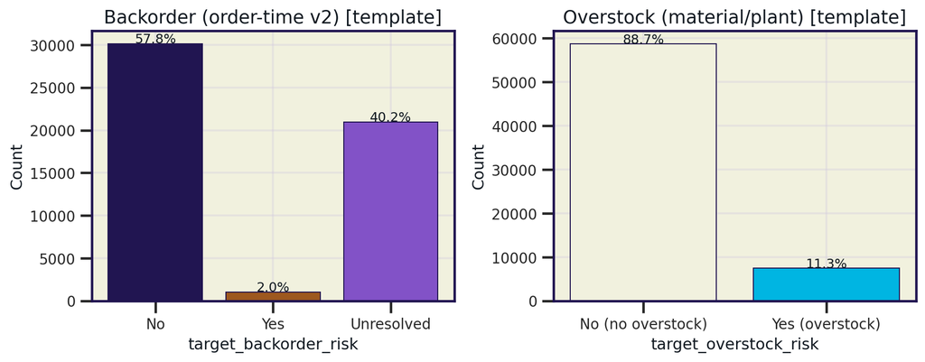

Temporal Positive Rate Drift

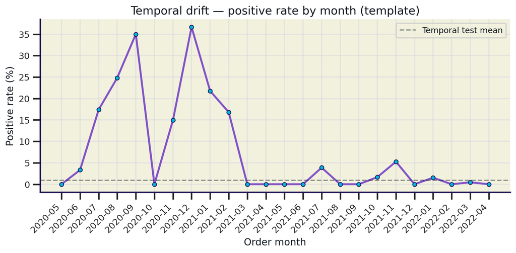

Drift / Performance Overlay

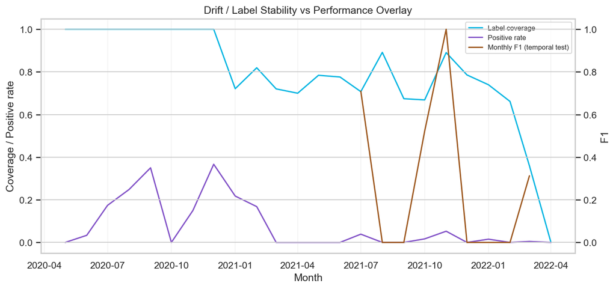

Temporal Snapshot (Live)

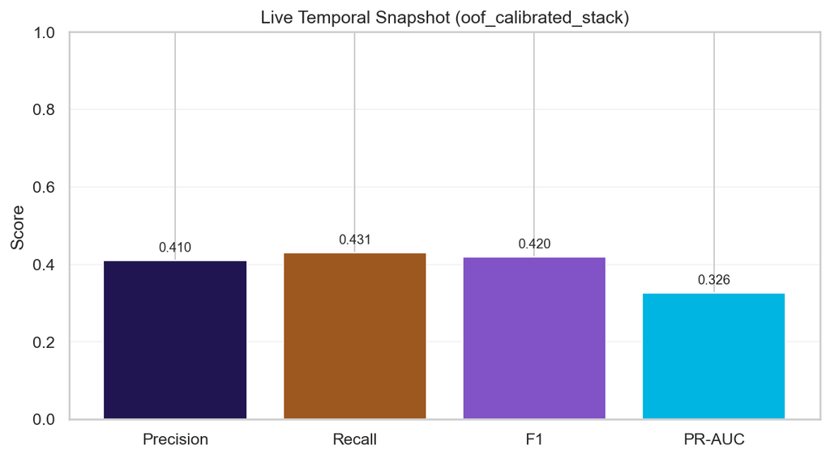

95% Bootstrap CI Error Bars

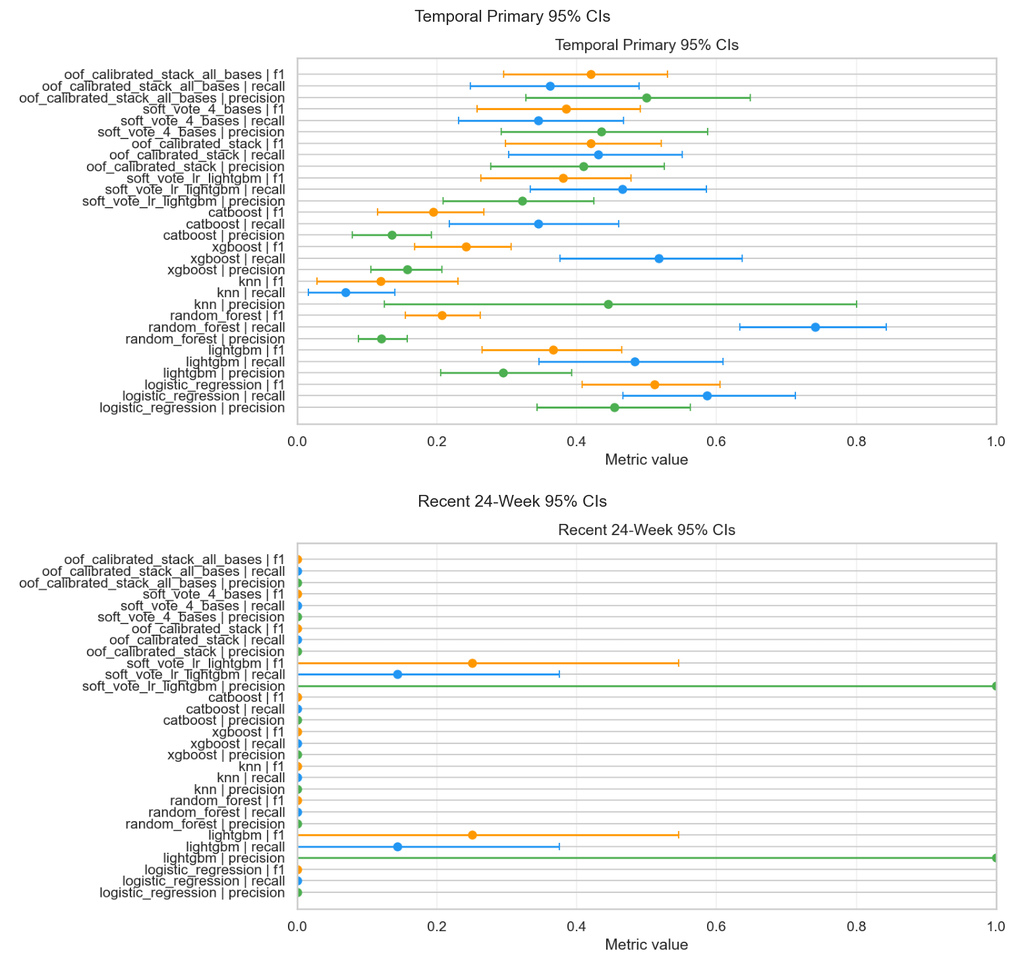

Decision Curve Analysis

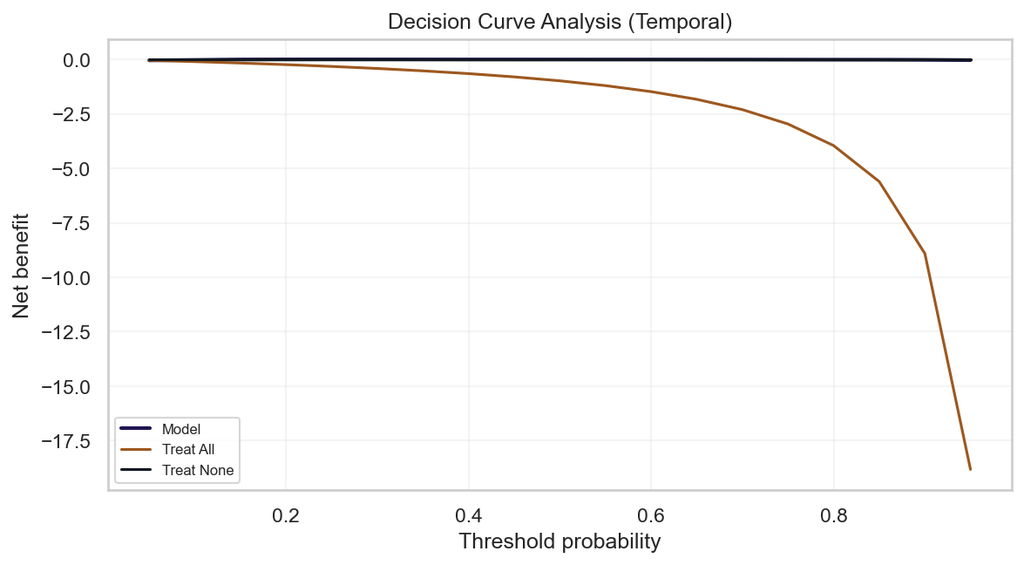

Calibration with Confidence Bands

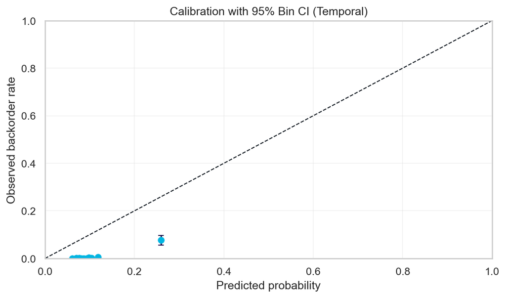

### Performance & Discrimination

Temporal ROC Curves

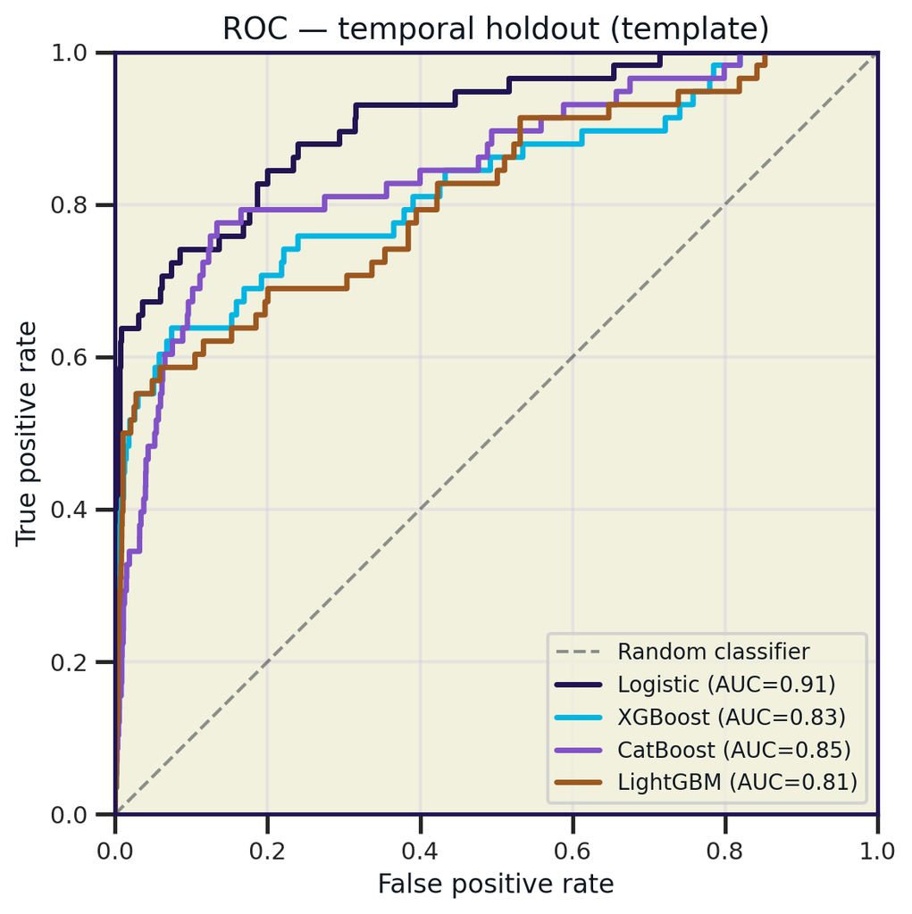

Temporal PR Curves

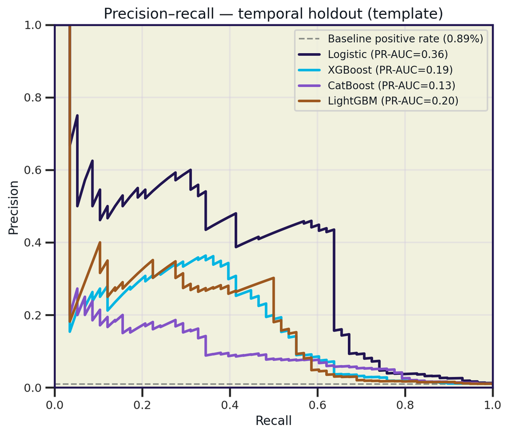

Model Comparison Heatmap (Live)

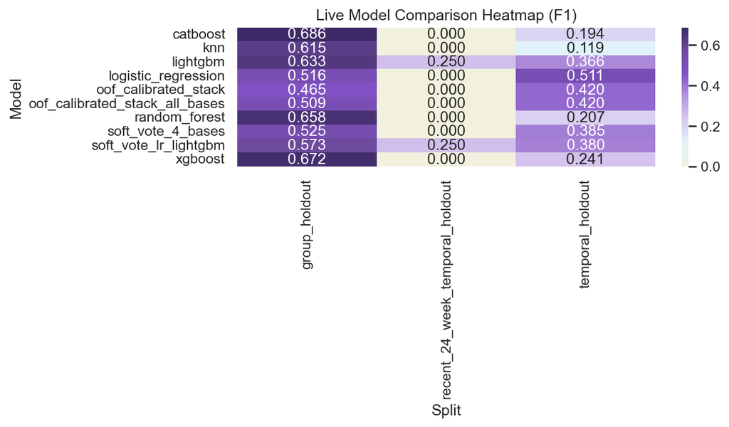

Confusion Matrices

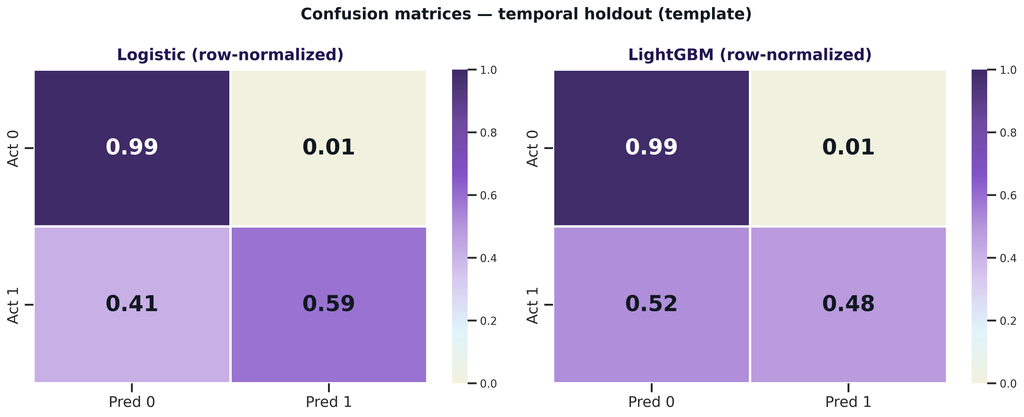

Temporal Score Distribution

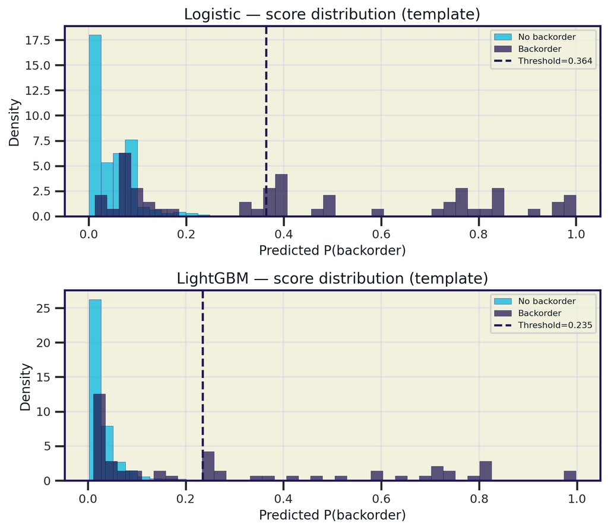

PR-Gain Curve

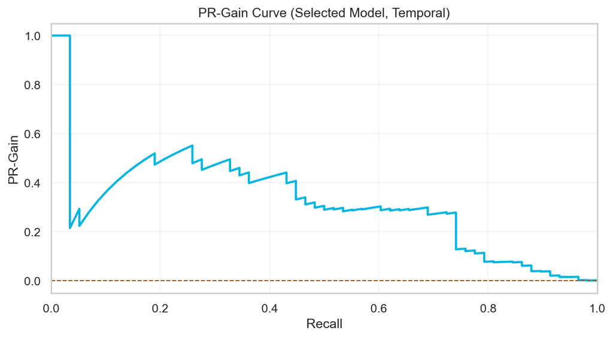

DET Curve

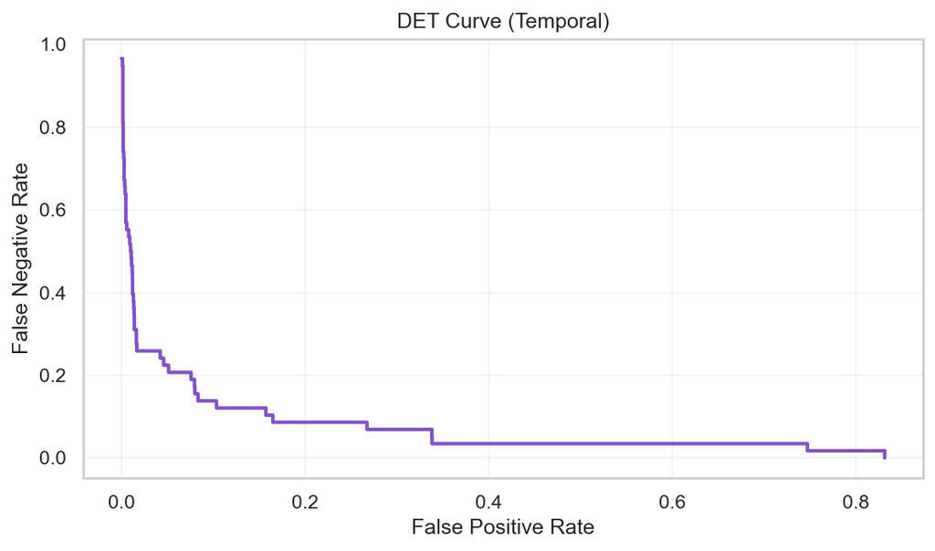

Lift and Cumulative Gains

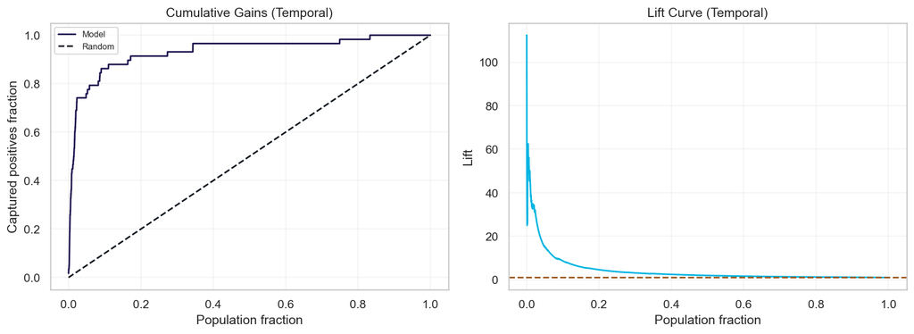

KS Curve

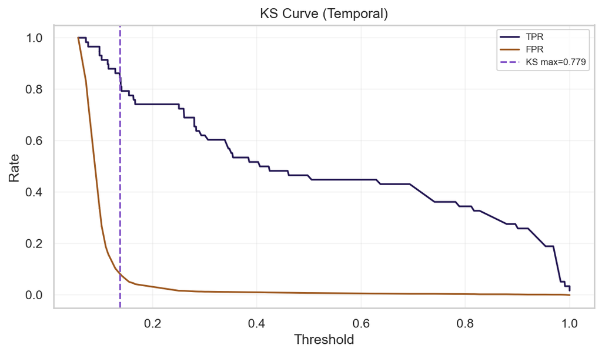

Precision-Recall Scatter by Split

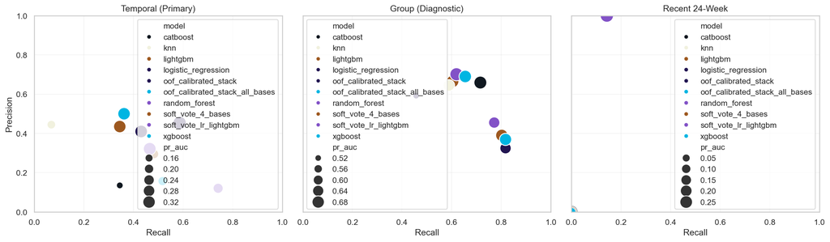

Bootstrap F1 Lift Distribution (p-value style)

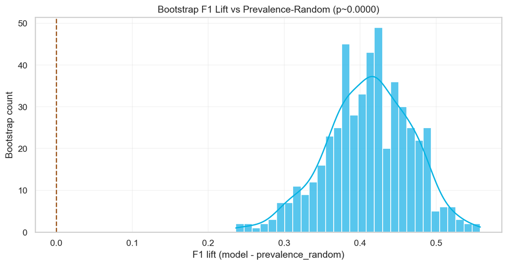

### Interpretability & Feature Evidence

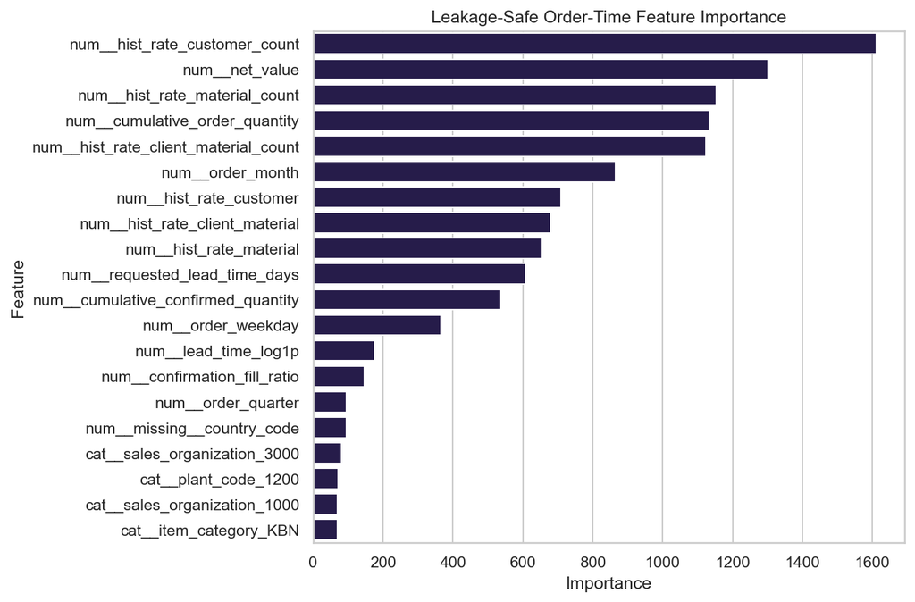

Permutation Importance with CI

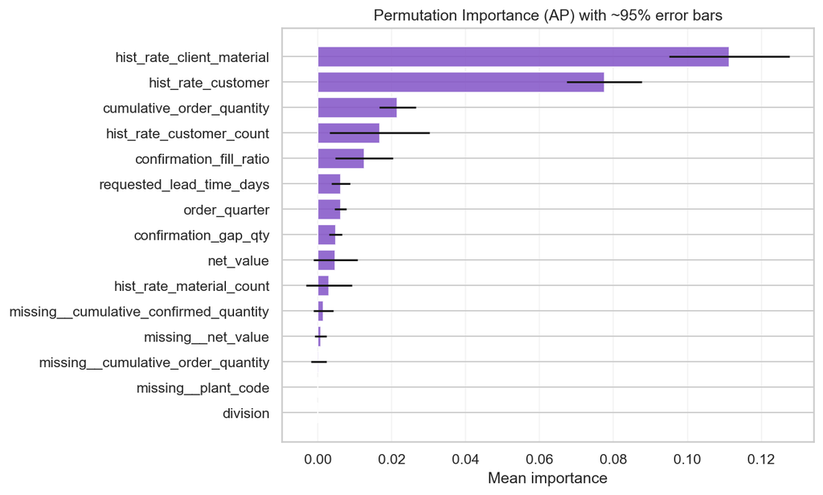

PDP + ICE (Top 3 Numeric Features)

[figure not shown]

Brier Decomposition

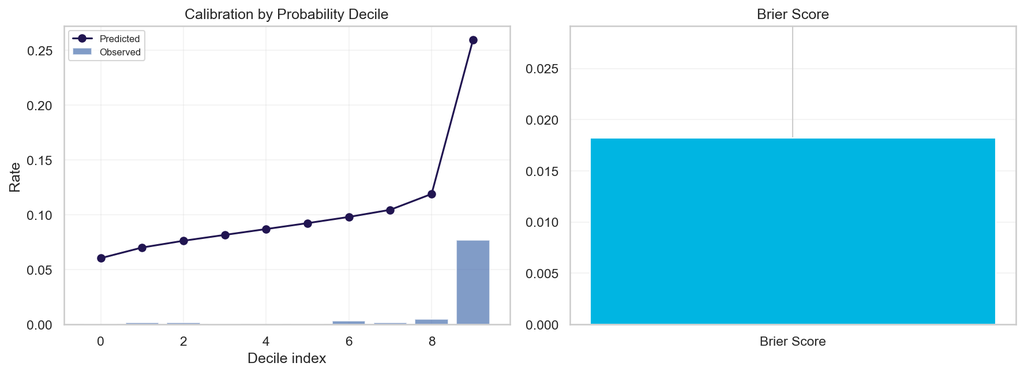

## Evidence by Model

Per-estimator rasters when available (e.g. feature importance). Multi-model curves and heatmaps stay in Evidence Charts (shared) above.

## Logistic Regression

### Interpretability & Feature Evidence

Feature importance (Logistic Regression)

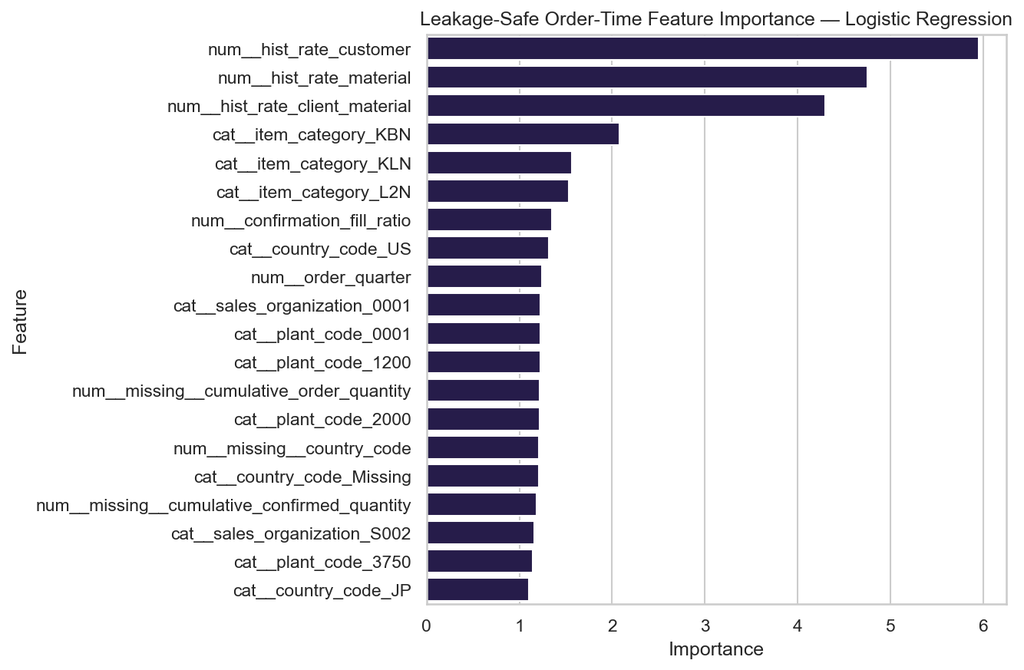

## Lightgbm

### Interpretability & Feature Evidence

Feature importance (Lightgbm)

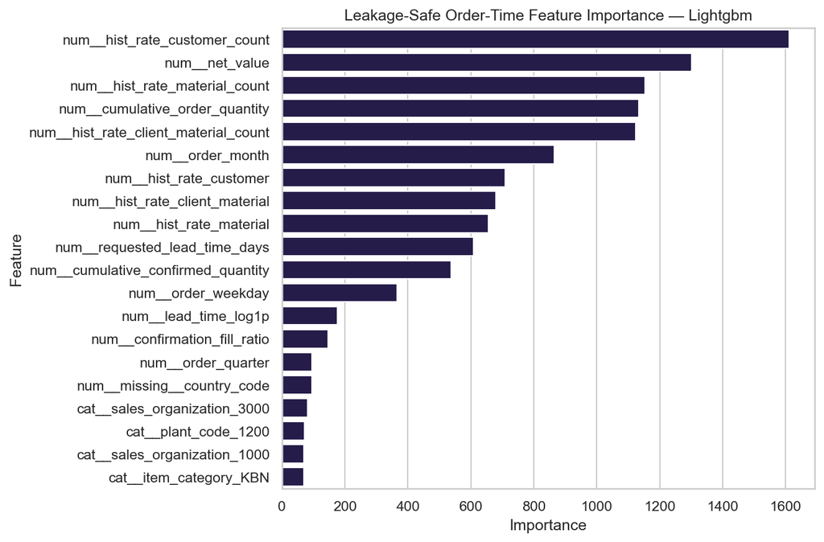

## Xgboost

### Interpretability & Feature Evidence

Feature importance (Xgboost)

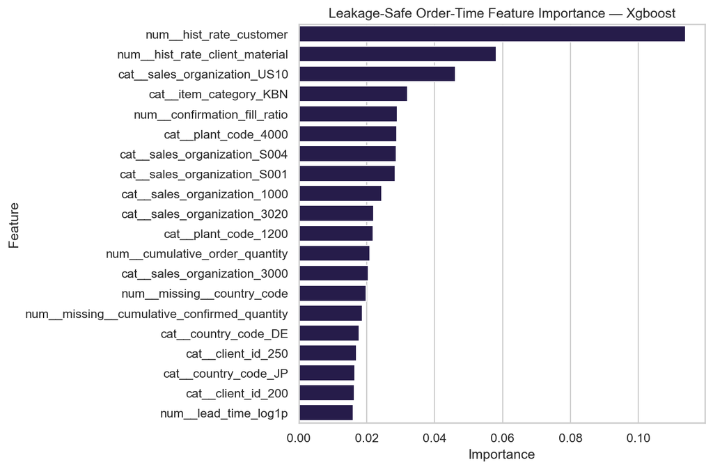

## Catboost

### Interpretability & Feature Evidence

Feature importance (Catboost)

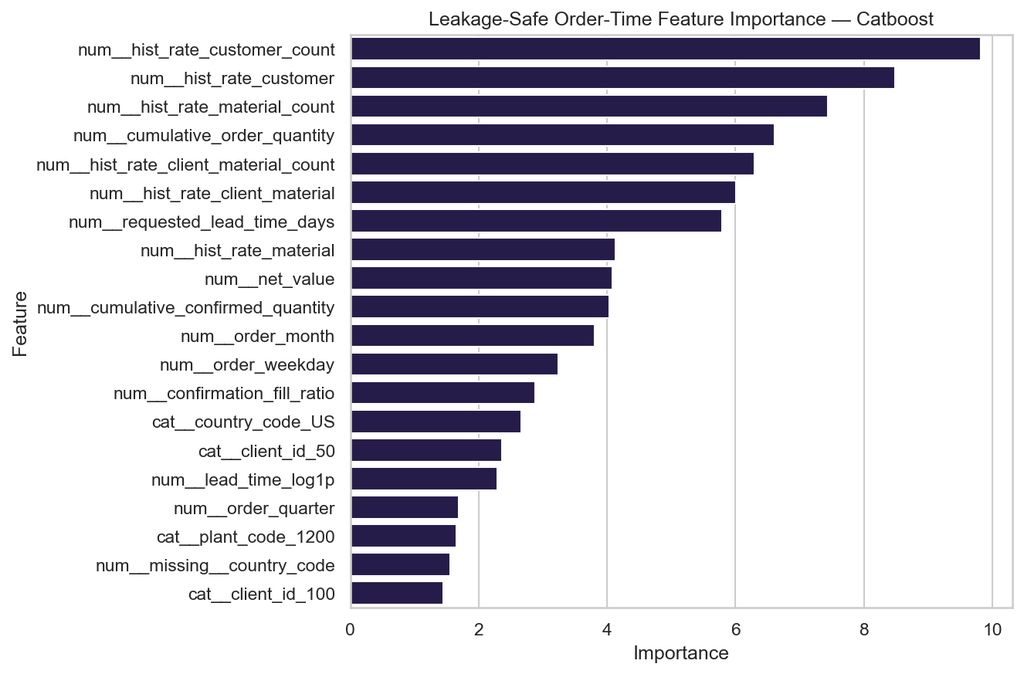

## Knn

### Interpretability & Feature Evidence

Feature importance (Knn)

[figure not shown]

## Random Forest

### Interpretability & Feature Evidence

Feature importance (Random Forest)

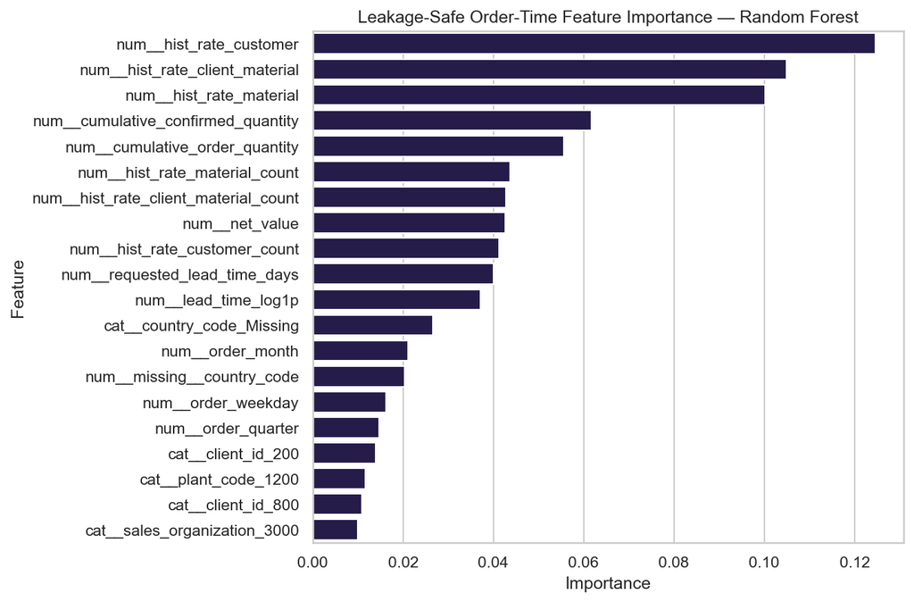